# softimpute analysis pipeline - site scale (50 iterations)

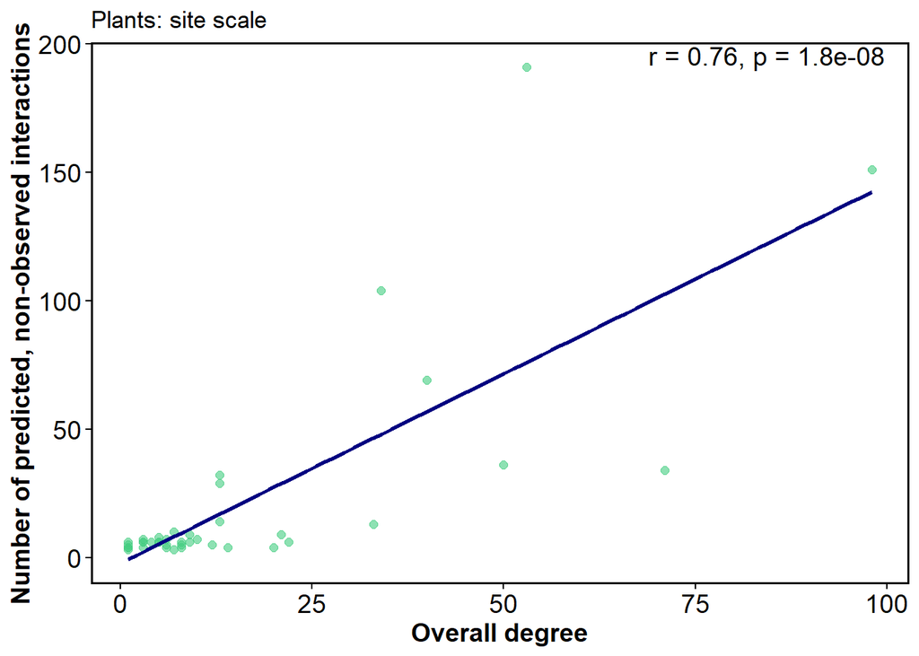

```r
# Extract correlation coefficient and p-value
r_value <- round(correlation_plants$estimate, 2)
p_value <- formatC(correlation_plants$p.value, digits = 2)  # or round as you prefer
label_text_plants <- paste0("r = ", r_value, ", p = ", p_value)

plant_degree <- ggplot(df_to_correlate, aes(x = x, y = y)) +
  geom_point(alpha = 0.6, size = 2, color = "seagreen3") +
  geom_smooth(method = "lm", se = FALSE, color = "navy") +
  labs(
    x = "Overall degree",
    y = "Number of predicted, non-observed interactions",
    title = "Plants: site scale"
  ) +
  theme_minimal() + tme +
  annotate("text",
           x = Inf,
           y = Inf,
           hjust = 1.1,
           vjust = 1.2,   # Adjust depending on your data range
           label = label_text_plants,
           size = 5,
           color = "black")
plant_degree
```

```r
df_to_correlate <- never_poll_degree_overall
df_to_correlate$x <- df_to_correlate$overall_poll_degree
df_to_correlate$y <- df_to_correlate$count_never_observed

correlation_poll <- cor.test(df_to_correlate$x, df_to_correlate$y, use = "complete.obs", method = "pearson")
correlation_poll
```

```
##
##  Pearson's product-moment correlation
##
## data:  df_to_correlate$x and df_to_correlate$y
## t = 8.141, df = 244, p-value = 2.018e-14
## alternative hypothesis: true correlation is not equal to 0
## 95 percent confidence interval:
##  0.3577806 0.5551547
## sample estimates:
##       cor
## 0.4621723
```

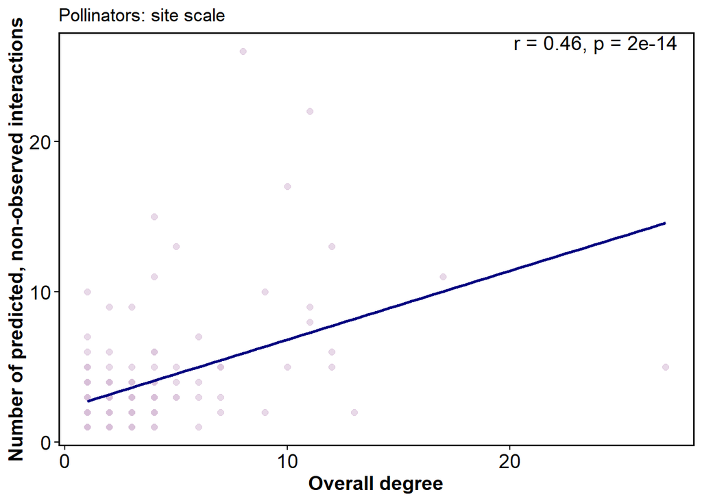

```r
# Extract correlation coefficient and p-value
r_value <- round(correlation_poll$estimate, 2)
p_value <- formatC(correlation_poll$p.value, digits = 2)  # or round as you prefer
label_text_polls <- paste0("r = ", r_value, ", p = ", p_value)

poll_degree <- ggplot(df_to_correlate, aes(x = x, y = y)) +
  geom_point(alpha = 0.6, size = 2, color = "thistle") +
  geom_smooth(method = "lm", se = FALSE, color = "navy") +
  labs(
    x = "Overall degree",
    y = "Number of predicted, non-observed interactions",
    title = "Pollinators: site scale"
  ) +
  theme_minimal() + tme +
  annotate("text",
           x = Inf,
           y = Inf,
           hjust = 1.1,
           vjust = 1.2,   # Adjust depending on your data range
           label = label_text_polls,
           size = 5,
           color = "black")
poll_degree
```

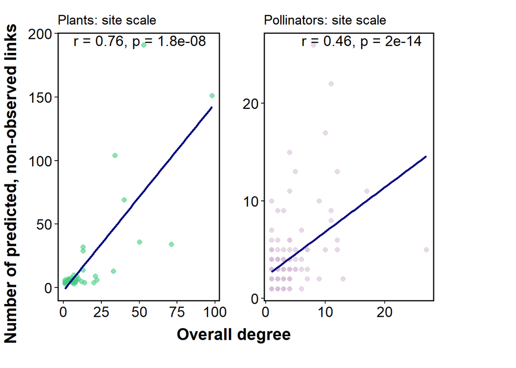

```r
final_plot <- combine_plots(plant_degree, poll_degree)
```

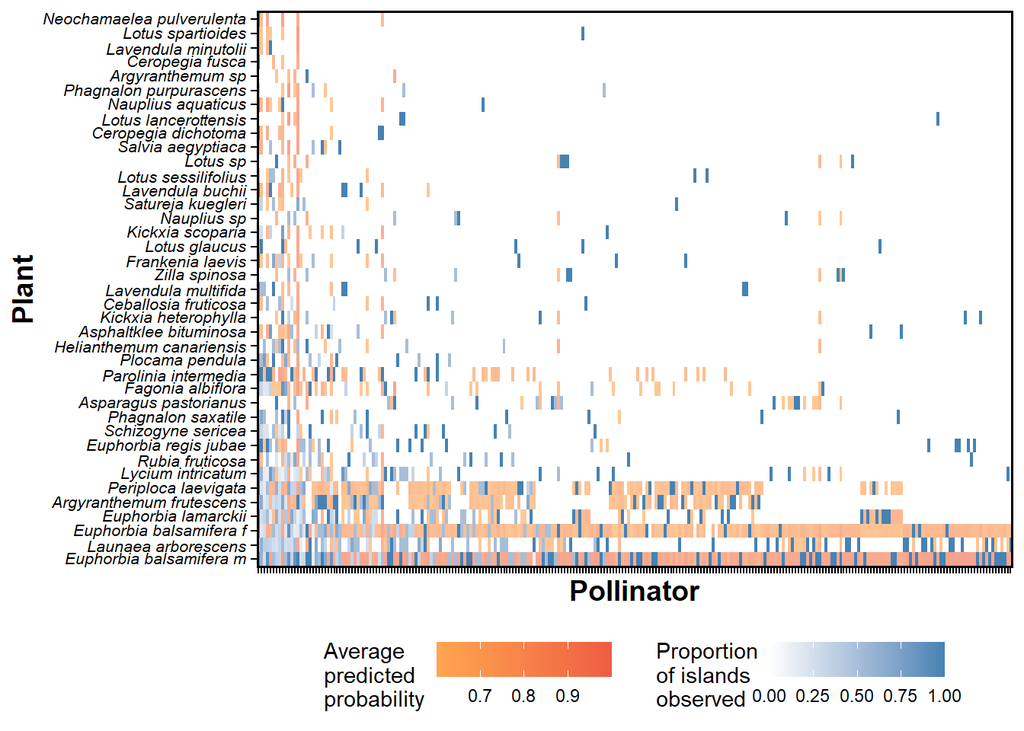

```r
## ---- never-observed links ----
### ---- heatmap related to island proportion ----
# here we visualize the links that were never observed yet predicted to exist by the algorithm, and alongside them interactions that were observed, and the proportion of islands in which these interactions were observed.

# order species by their degree
df_summary <- df_summary %>% left_join(overall_poll_degree, by="node_to")
df_summary <- df_summary %>% left_join(overall_plant_degree, by="node_from")

# Determine the order for plants based on overall_plant_degree
plant_order <- df_summary %>%
  distinct(node_from, overall_plant_degree) %>%
  arrange(desc(overall_plant_degree)) %>%
  pull(node_from)

# Determine the order for pollinators based on overall_poll_degree
poll_order <- df_summary %>%
  distinct(node_to, overall_poll_degree) %>%
  arrange(desc(overall_poll_degree)) %>%
  pull(node_to)

# Reset the levels for the species factors
df_summary$node_from <- factor(df_summary$node_from, levels = plant_order)
df_summary$node_to   <- factor(df_summary$node_to, levels = poll_order)


ggplot(df_summary, aes(x = node_to, y = node_from)) +
  # First layer: background heatmap for proportion observed (blue gradient)
  geom_tile(aes(fill = avg_prop)) +
  scale_fill_gradient(low = "white", high = "steelblue",
                      name = "Proportion\nof islands\nobserved") +

  # Reset fill scale so the next layer can have its own gradient
  new_scale_fill() +

  # Second layer: overlay only cells that were never observed but have high predicted value
  geom_tile(
    data = df_summary %>% filter(avg_prop == 0, avg_sigm_predicted > best_discrete_threshold),
    aes(fill = avg_sigm_predicted),
    alpha = 0.6
  ) +
  scale_fill_gradient(low = "tan1", high = "tomato2",
                      name = "Average \npredicted \nprobability") +

  # Final adjustments
  theme_minimal() +
  labs(x = "Pollinator", y = "Plant") +
  theme(
    axis.text.x = element_blank(),
    axis.text.y = element_text(size = 8),
    legend.position = "bottom",         # Place legends at the bottom
    legend.box = "horizontal"
  ) + tme +
  scale_y_discrete(labels = function(x) lapply(strsplit(x, "_"), function(y) {
    bquote(italic(.(paste(y, collapse = " "))))
  }))
```

```r
### ---- detect interactions that were never observed in the field yet consistently predicted to exist ----
# filter the interactions that were always observed as zeros yet predicted to exist
df_all_itr_zero <- df %>%
  group_by(node_from, node_to) %>%
  # Check if all rows for that interaction have original_links == 0
  filter(all(original_links == 0)) %>%
  filter(removed == 1) %>%
  filter(predicted_prob_sigm > best_discrete_threshold) %>%
  ungroup()

# filter only links that appear several times for the analysis
predicted_links <- df_all_itr_zero %>%
  group_by(node_from, node_to) %>%
  # Keep only those links/groups with >= 5 observations
  filter(n() >= 5) %>%
  summarise(
    n         = n(),
    mean_pred = mean(predicted_prob_sigm, na.rm = TRUE),
    sd_pred   = sd(predicted_prob_sigm, na.rm = TRUE),  # to check variance
    p_value   = if (sd_pred == 0) {
      NA_real_  # can't run a t-test if there's no variance
    } else {
      t.test(predicted_prob_sigm, mu = best_discrete_threshold)$p.value
    },
    .groups   = "drop"
  )

predicted_links %>%
  arrange(desc(mean_pred)) %>%
  head(10)
```

```
## # A tibble: 10 × 6
##    node_from               node_to                 n mean_pred sd_pred   p_value
##    <chr>                   <chr>               <int>     <dbl>   <dbl>     <dbl>
##  1 Lotus_glaucus           Camponotus_feae        35     1.00  8.29e-5 4.74e-127
##  2 Lotus_spartioides       Camponotus_feae        24     1.00  1.86e-4 2.19e- 78
##  3 Lavendula_minutolii     Camponotus_feae        21     1.00  1.50e-4 3.36e- 70
##  4 Salvia_aegyptiaca       Camponotus_feae        49     0.998 7.72e-3 4.62e- 84
##  5 Lotus_lancerottensis    Plagiolepis_schmit…    28     0.996 1.14e-2 2.33e- 43
##  6 Phagnalon_purpurascens  Camponotus_feae        23     0.995 1.15e-2 1.54e- 35
##  7 Lotus_lancerottensis    Thysanoptera_sp_1      29     0.992 6.95e-3 8.24e- 51
##  8 Phagnalon_purpurascens  Plagiolepis_schmit…    62     0.990 2.32e-2 1.13e- 76
##  9 Lavendula_minutolii     Thysanoptera_sp_1      28     0.982 4.75e-2 2.84e- 26
## 10 Euphorbia_balsamifera_m Leptochilus_fortun…    27     0.975 2.71e-2 1.94e- 31
```

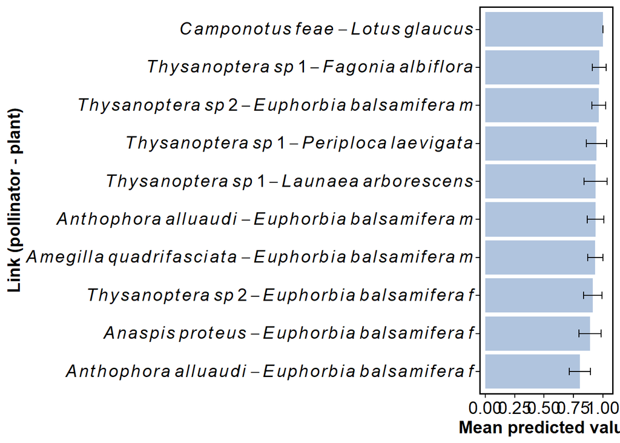

```r
#write.csv(predicted_links, 'links_probability_to_be_non_zeros.csv')

df_summary_sign <- predicted_links %>% filter(p_value < 0.05)

df_top_10 <- predicted_links %>%
  # Order by ascending p-value
  arrange(p_value) %>%
  # Take the first 10 rows
  slice(1:10)

ggplot(df_top_10,
       aes(x = reorder(paste(node_to, node_from, sep = " - "), mean_pred),
           y = mean_pred,
           fill = p_value < 0.05)) +
  geom_col(fill = "lightsteelblue") +
  geom_errorbar(aes(ymin = mean_pred - sd_pred, ymax = mean_pred + sd_pred),
                width = 0.2) +
  coord_flip() +
  #scale_fill_manual(name = "Significant?", values = c("gray70", "tomato")) +
  tme +
  scale_x_discrete(
    labels = function(x) sapply(x, function(lbl) {
      # 1) Replace underscores with a tilde (for spacing in plotmath)
      #    e.g., "Euphorbia_balsamifera_f" => "Euphorbia~balsamifera~f"
      lbl_tilde <- gsub("_", "~", lbl)
      # 2) Wrap in italic(), so the entire thing is in italics
      #    expression syntax: parse(text="italic(Euphorbia~balsamifera~f)")
      parse(text = paste0("italic(", lbl_tilde, ")"))
    })) +
  labs(
    x = "Link (pollinator - plant)",
    y = "Mean predicted value"
    #title = "Mean predicted value and significance"
  )
```

```r
## ---- distance effect ----
### ---- add distances and location names ----
distance_table <- read.csv("distance_between_sites_canary.csv", row.names = NULL)

# proceed for both island scale and site scale and compare the trends
### ---- island scale ----
# Function to extract island names (removes "_site_X")
extract_island <- function(name) {
  gsub("_site_[12]", "", name)
}

# Create new table with averaged distances at the island level
distance_island_table <- distance_table %>%
  mutate(
    from_island = extract_island(from),
    to_island = extract_island(to)
  ) %>%
  group_by(from_island, to_island) %>%
  summarise(
    avg_distance_m = mean(distance_m),
    avg_distance_km = mean(distance_km),
    .groups = "drop"
  ) %>%
  mutate(
    avg_distance_m = ifelse(from_island == to_island, 0, avg_distance_m),
    avg_distance_km = ifelse(from_island == to_island, 0, avg_distance_km)
  ) %>%
  rename(from = from_island, to = to_island)  # Rename after calculation

# Print result
print(distance_island_table)
```

```
## # A tibble: 49 × 4
##    from          to             avg_distance_m avg_distance_km
##    <chr>         <chr>                   <dbl>           <dbl>
##  1 El_Hierro     El_Hierro                  0              0
##  2 El_Hierro     Fuerteventura         455677.           456.
##  3 El_Hierro     Gran_Canaria          274347.           274.
##  4 El_Hierro     La_Gomera              80113.            80.1
##  5 El_Hierro     Tenerife_South        172763.           173.
##  6 El_Hierro     Tenerife_Teno         129414.           129.
##  7 El_Hierro     Western_Sahara        437371.           437.
##  8 Fuerteventura El_Hierro             455677.           456.
##  9 Fuerteventura Fuerteventura              0              0
## 10 Fuerteventura Gran_Canaria          190475.           190.
## # ℹ 39 more rows
```

```r
# Modify the 'from' and 'to' columns in distance_island_table
distance_island_table <- distance_island_table %>%
  mutate(from = gsub("_", " ", from),
         to = gsub("_", " ", to))

# Add names and distances to the main table
net <- emln::load_emln(60) # canary islands
```

```
## [1] "Creating state node map"
## [1] "Creating extended link list with node IDs"
```

```r
net$layers
```

```
## # A tibble: 14 × 5
##    layer_id name                  latitude longitude layer_name
##       <int> <chr>                    <dbl>     <dbl> <chr>
##  1        1 Tenerife_Teno_site_1      28.4     -16.9 layer_1
##  2        2 Tenerife_Teno_site_2      28.4     -16.9 layer_2
##  3        3 Tenerife_South_site_2     28.2     -16.4 layer_3
##  4        4 Tenerife_South_site_1     28.2     -16.4 layer_4
##  5        5 Gran_Canaria_site_2       27.9     -15.4 layer_5
##  6        6 Gran_Canaria_site_1       27.9     -15.4 layer_6
##  7        7 Fuerteventura_site_2      28.6     -13.9 layer_7
##  8        8 Fuerteventura_site_1      28.6     -13.9 layer_8
##  9        9 Western_Sahara_site_2     26.2     -14.4 layer_9
## 10       10 Western_Sahara_site_1     26.2     -14.4 layer_10
## 11       11 El_Hierro_site_2          27.8     -17.9 layer_11
## 12       12 El_Hierro_site_1          27.8     -17.9 layer_12
## 13       13 La_Gomera_site_2          28.0     -17.2 layer_13
## 14       14 La_Gomera_site_1          28.0     -17.2 layer_14
```

```r
net_name <- net$layers %>% select(layer_id, name)
net_name
```

```
## # A tibble: 14 × 2
##    layer_id name
##       <int> <chr>
##  1        1 Tenerife_Teno_site_1
##  2        2 Tenerife_Teno_site_2
##  3        3 Tenerife_South_site_2
##  4        4 Tenerife_South_site_1
##  5        5 Gran_Canaria_site_2
##  6        6 Gran_Canaria_site_1
##  7        7 Fuerteventura_site_2
##  8        8 Fuerteventura_site_1
##  9        9 Western_Sahara_site_2
## 10       10 Western_Sahara_site_1
## 11       11 El_Hierro_site_2
## 12       12 El_Hierro_site_1
## 13       13 La_Gomera_site_2
## 14       14 La_Gomera_site_1
```

```r
net_name <- net_name %>%
  mutate(name = gsub("_", " ", name))

# Step 1: Create a new grouped tibble
new_layer_names <- net_name %>%
  mutate(group_id = (layer_id + 1) %/% 2) %>%  # Group pairs into 1, 2, 3...
  group_by(group_id) %>%
  summarise(name = gsub(" site.*", "", first(name)), .groups = "drop")  # Keep only location name

# Add to main table
#result_summary_island <- read_csv('working_df_all_itr_60_weighted_scaled_island_50_itr.csv')
result_island <- read_csv('weighted__scaled_island_net_60_50_itr.csv')
df_removed_island <- result_island %>%
  filter(removed == 1) %>%
  mutate(predicted_prob_sigm = sigmoid(predicted_values)) %>%  # convert the predicted values to probability values in the interval (0, 1) using the logistic function
  mutate(predicted_bin_sigm = if_else(predicted_prob_sigm > best_discrete_threshold, 1, 0)) %>%
  mutate(original_binary = if_else(original_links > 0, 1, 0))

result_summary_island <- df_removed_island %>%
  group_by(emln_id, train_layer, test_layer, itr) %>%
  summarise(
    TP = sum(original_binary == 1 & predicted_bin_sigm == 1),
    FN = sum(original_binary == 1 & predicted_bin_sigm == 0),
    TN = sum(original_binary == 0 & predicted_bin_sigm == 0),
    FP = sum(original_binary == 0 & predicted_bin_sigm == 1),
    specificity = TN / (TN + FP),
    precision = TP / (TP + FP),
    recall = TP / (TP + FN),
    f1_score = 2 * (precision * recall) / (precision + recall),
    balanced_accuracy = (recall + specificity) / 2,
    mcc = (TP * TN - FP * FN) / sqrt((TP + FP) * (TP + FN) * (TN + FP) * (TN + FN)),
    mse = mean((predicted_values - original_links)^2, na.rm = TRUE),
    rmse = sqrt(mse)
  ) %>%
  ungroup() %>%
  group_by(emln_id, train_layer, test_layer) %>%
  summarise(
    TP = mean(TP, na.rm = TRUE),
    FN = mean(FN, na.rm = TRUE),
    TN = mean(TN, na.rm = TRUE),
    FP = mean(FP, na.rm = TRUE),
    specificity = mean(specificity, na.rm = TRUE),
    precision = mean(precision, na.rm = TRUE),
    recall = mean(recall, na.rm = TRUE),
    f1_score = mean(f1_score, na.rm = TRUE),
    balanced_accuracy = mean(balanced_accuracy, na.rm = TRUE),
    mcc = mean(mcc, na.rm = TRUE),
    mse = mean(mse, na.rm = TRUE),
    rmse = mean(rmse, na.rm = TRUE)
  ) %>%
  ungroup()
```

```
## can override using the `.groups` argument.
```

```r
result_summary_island <- result_summary_island %>%
  left_join(new_layer_names, by = c("train_layer" = "group_id")) %>%
  rename(train_layer_name = name) %>%
  left_join(new_layer_names, by = c("test_layer" = "group_id")) %>%
  rename(test_layer_name = name)

# Add to main table
result_summary_island <- result_summary_island %>%
  left_join(
    distance_island_table,
    by = c("train_layer_name" = "from", "test_layer_name" = "to")
  ) %>%
  mutate(distance_km = if_else(train_layer_name == test_layer_name,
                               0,              # distance = 0 if same site
                               avg_distance_km))   # otherwise, keep joined distance

### ---- site scale ----
# Add names and distances to the main table
net <- emln::load_emln(60) # canary islands
```

```
## [1] "Creating state node map"
## [1] "Creating extended link list with node IDs"
```

```r
net$layers
```

```
## # A tibble: 14 × 5
##    layer_id name                  latitude longitude layer_name
##       <int> <chr>                    <dbl>     <dbl> <chr>
##  1        1 Tenerife_Teno_site_1      28.4     -16.9 layer_1
##  2        2 Tenerife_Teno_site_2      28.4     -16.9 layer_2
##  3        3 Tenerife_South_site_2     28.2     -16.4 layer_3
##  4        4 Tenerife_South_site_1     28.2     -16.4 layer_4
##  5        5 Gran_Canaria_site_2       27.9     -15.4 layer_5
##  6        6 Gran_Canaria_site_1       27.9     -15.4 layer_6
##  7        7 Fuerteventura_site_2      28.6     -13.9 layer_7
##  8        8 Fuerteventura_site_1      28.6     -13.9 layer_8
##  9        9 Western_Sahara_site_2     26.2     -14.4 layer_9
## 10       10 Western_Sahara_site_1     26.2     -14.4 layer_10
## 11       11 El_Hierro_site_2          27.8     -17.9 layer_11
## 12       12 El_Hierro_site_1          27.8     -17.9 layer_12
## 13       13 La_Gomera_site_2          28.0     -17.2 layer_13
## 14       14 La_Gomera_site_1          28.0     -17.2 layer_14
```

```r
net_name <- net$layers %>% select(layer_id, name)
net_name
```

```
## # A tibble: 14 × 2
##    layer_id name
##       <int> <chr>
##  1        1 Tenerife_Teno_site_1
##  2        2 Tenerife_Teno_site_2
##  3        3 Tenerife_South_site_2
##  4        4 Tenerife_South_site_1
##  5        5 Gran_Canaria_site_2
##  6        6 Gran_Canaria_site_1
##  7        7 Fuerteventura_site_2
##  8        8 Fuerteventura_site_1
##  9        9 Western_Sahara_site_2
## 10       10 Western_Sahara_site_1
## 11       11 El_Hierro_site_2
## 12       12 El_Hierro_site_1
## 13       13 La_Gomera_site_2
## 14       14 La_Gomera_site_1
```

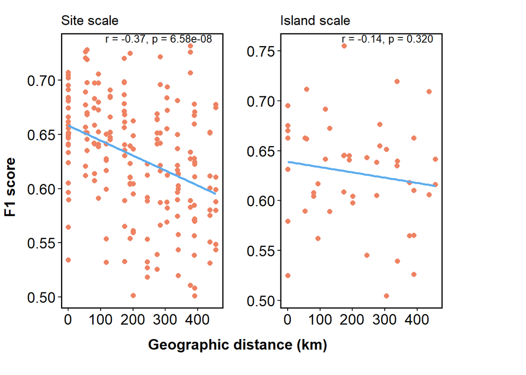

```r
net_name <- net_name %>%
  mutate(name = gsub("_", " ", name))

# Modify the 'from' and 'to' columns in distance_table
distance_table <- distance_table %>%
  mutate(from = gsub("_", " ", from),
         to = gsub("_", " ", to))

# Assuming your lookup tibble is called net_name and has columns layer_id and name

result_summary <- result_summary %>%
  # Join to add train_layer_name
  left_join(net_name %>%
              rename(train_layer = layer_id,
                     train_layer_name = name),
            by = "train_layer") %>%
  # Join to add test_layer_name
  left_join(net_name %>%
              rename(test_layer = layer_id,
                     test_layer_name = name),
            by = "test_layer")


# Add to main table
result_summary <- result_summary %>%
  left_join(
    distance_table,
    by = c("train_layer_name" = "from", "test_layer_name" = "to")
  ) %>%
  mutate(distance_km = if_else(train_layer_name == test_layer_name,
                               0,              # distance = 0 if same site
                               distance_km))   # otherwise, keep joined distance

write.csv(result_summary, 'working_df_site_scaled_evaluators_distance_50_itr_net_60.csv')

result_summary_site <- result_summary

## ---- distance correlation with evaluators ----
make_cor_plot <- function(data, evaluator,
                          distance_col = "distance_km",
                          x_lab = "Geographic distance (km)",
                          y_lab = NULL,
                          extra_theme = NULL) {
  # Use evaluator as y_lab if no alternative is provided
  if (is.null(y_lab)) {
    y_lab <- evaluator
  }

  # Compute correlation between evaluator and distance
  correlation <- cor.test(data[[evaluator]], data[[distance_col]],
                          use = "complete.obs", method = "pearson")
  r_value <- round(correlation$estimate, 2)
  p_value <- ifelse(
    correlation$p.value < 0.001,
    formatC(correlation$p.value, format = "e", digits = 2),  # scientific for very small
    formatC(correlation$p.value, format = "f", digits = 3)   # fixed format otherwise
  )
  label_text <- paste0("r = ", r_value, ", p = ", p_value)

  # Create plot with label in the upper right corner using Inf coordinates
  plot <- ggplot(data, aes_string(x = distance_col, y = evaluator)) +
    geom_point(color = "salmon2", size = 2) +
    geom_smooth(method = "lm", se = FALSE, color = "steelblue2") +
    labs(x = x_lab, y = y_lab) +
    # The following places the label at the upper right of the plot area
    annotate("text", x = Inf, y = Inf, label = label_text,
             hjust = 1.1, vjust = 1.1, size = 3.5, color = "black")

  # Optionally add additional theme modifications
  if (!is.null(extra_theme)) {
    plot <- plot + extra_theme
  }

  return(plot)
}

combine_two_plots <- function(p1, p2,
                              x_axis_label = "Geographic distance (km)",
                              y_axis_label = "F1 score",
                              p1_title = "Site scale",
                              p2_title = "Island scale",
                              margins = unit(c(0.5, 0.5, 1, 0.3), "cm"),
                              axis_title_fontsize = 14,
                              axis_title_fontface = "bold") {

  # Adjust first plot
  p1 <- p1 +
    ggtitle(p1_title) +
    theme(
      legend.position = "none",
      axis.title = element_blank(),
      plot.margin = margins
    )

  # Adjust second plot
  p2 <- p2 +
    ggtitle(p2_title) +
    theme(
      legend.position = "none",
      axis.title = element_blank(),
      plot.margin = margins
    )

  # Combine p1 and p2 side by side
  combined_plots <- arrangeGrob(
    p1, p2,
    ncol = 2,
    widths = c(1, 1)
  )

  # Add global x and y axis labels
  combined_with_axes <- arrangeGrob(
    combined_plots,
    bottom = textGrob(
      x_axis_label,
      gp = gpar(fontsize = axis_title_fontsize, fontface = axis_title_fontface),
      vjust = -1.5
    ),
    left = textGrob(
      y_axis_label,
      rot = 90,
      gp = gpar(fontsize = axis_title_fontsize, fontface = axis_title_fontface)
    )
  )

  # Final arrangement
  final_plot <- grid.arrange(
    combined_with_axes,
    ncol = 2,
    widths = c(2, 0.3)
  )

  return(final_plot)
}

cor_plot_site_f1 <- make_cor_plot(result_summary_site, evaluator = "f1_score", extra_theme = tme)
cor_plot_isl_f1  <- make_cor_plot(result_summary_island, evaluator = "f1_score", extra_theme = tme)
final_plot_f1 <- combine_two_plots(cor_plot_site_f1, cor_plot_isl_f1)
```

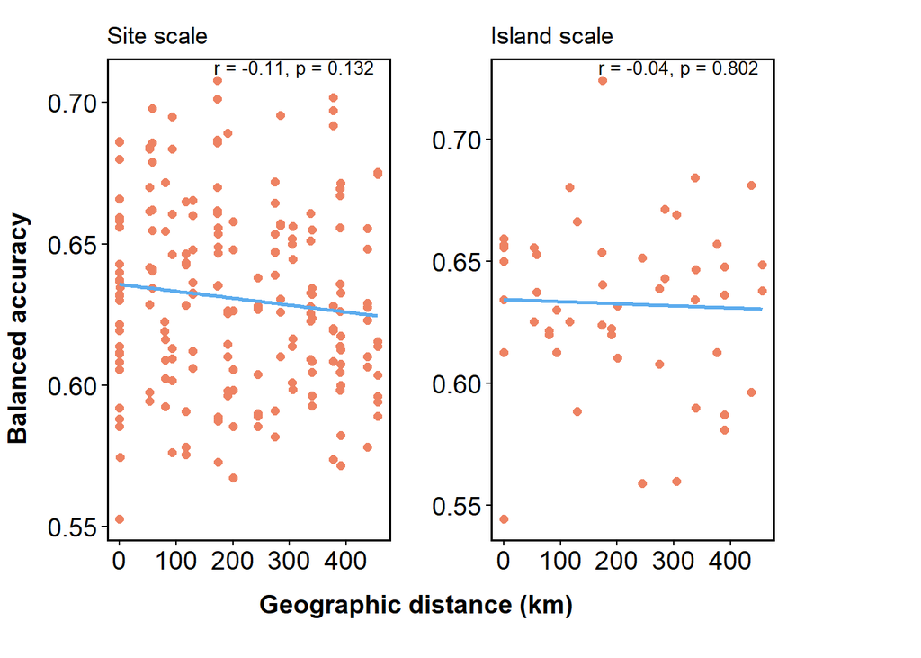

```r
cor_plot_site_ba <- make_cor_plot(result_summary_site, evaluator = "balanced_accuracy", extra_theme = tme)
cor_plot_isl_ba  <- make_cor_plot(result_summary_island, evaluator = "balanced_accuracy", extra_theme = tme)
final_plot_ba <- combine_two_plots(cor_plot_site_ba, cor_plot_isl_ba, y_axis_label = "Balanced accuracy")
```

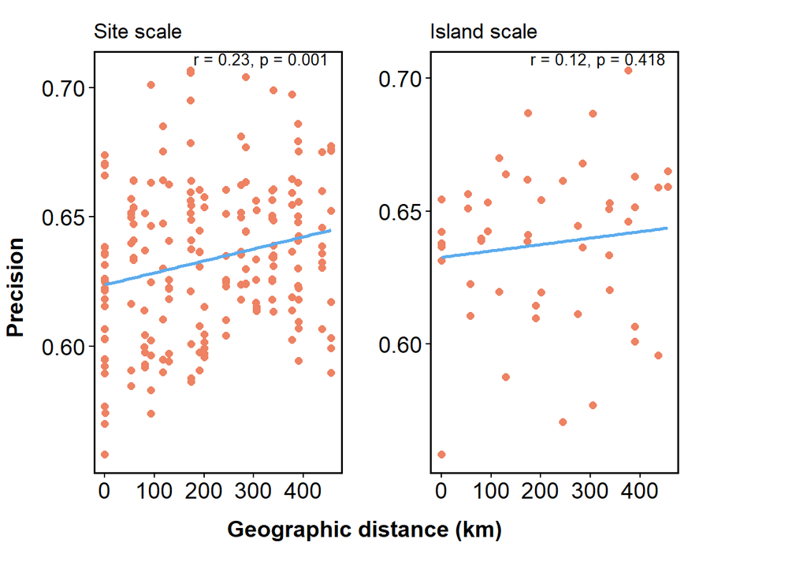

```r
cor_plot_site_precision <- make_cor_plot(result_summary_site, evaluator = "precision", extra_theme = tme)
cor_plot_isl_precision  <- make_cor_plot(result_summary_island, evaluator = "precision", extra_theme = tme)
final_plot_precision <- combine_two_plots(cor_plot_site_precision, cor_plot_isl_precision, y_axis_label = "Precision")
```

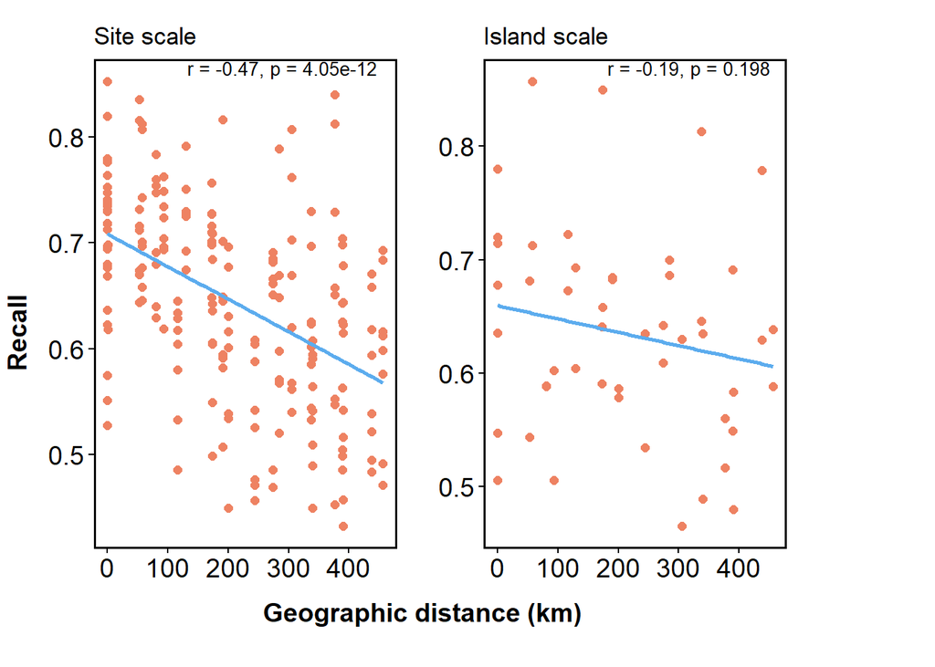

```r
cor_plot_site_recall <- make_cor_plot(result_summary_site, evaluator = "recall", extra_theme = tme)
cor_plot_isl_recall  <- make_cor_plot(result_summary_island, evaluator = "recall", extra_theme = tme)
final_plot_recall <- combine_two_plots(cor_plot_site_recall, cor_plot_isl_recall, y_axis_label = "Recall")
```

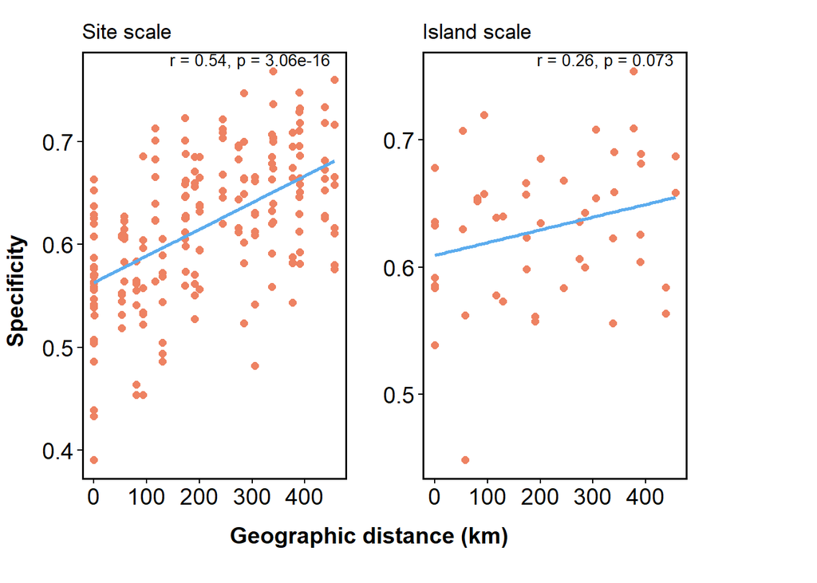

```r
cor_plot_site_specificity <- make_cor_plot(result_summary_site, evaluator = "specificity", extra_theme = tme)
cor_plot_isl_specificity  <- make_cor_plot(result_summary_island, evaluator = "specificity", extra_theme = tme)
final_plot_specificity <- combine_two_plots(cor_plot_site_specificity, cor_plot_isl_specificity, y_axis_label = "Specificity")
```

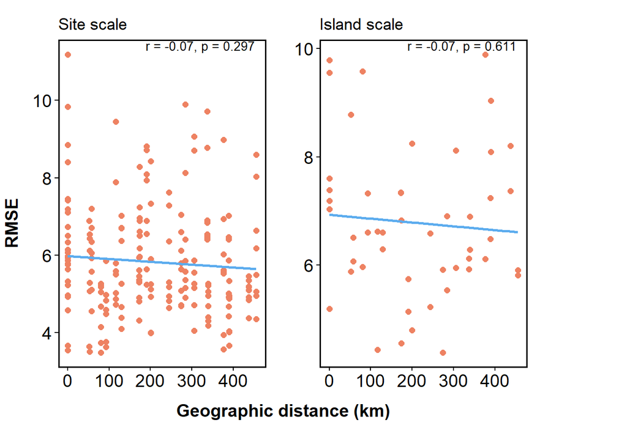

```r
cor_plot_site_rmse <- make_cor_plot(result_summary_site, evaluator = "rmse", extra_theme = tme)
cor_plot_isl_rmse  <- make_cor_plot(result_summary_island, evaluator = "rmse", extra_theme = tme)
final_plot_rmse <- combine_two_plots(cor_plot_site_rmse, cor_plot_isl_rmse, y_axis_label = "RMSE")
```

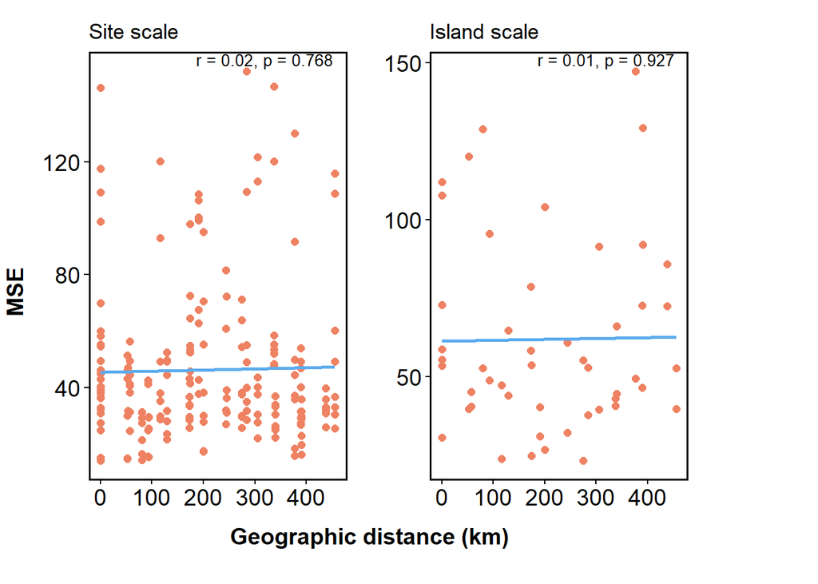

```r
cor_plot_site_mse <- make_cor_plot(result_summary_site, evaluator = "mse", extra_theme = tme)
cor_plot_isl_mse  <- make_cor_plot(result_summary_island, evaluator = "mse", extra_theme = tme)
final_plot_mse <- combine_two_plots(cor_plot_site_mse, cor_plot_isl_mse, y_axis_label = "MSE")
```

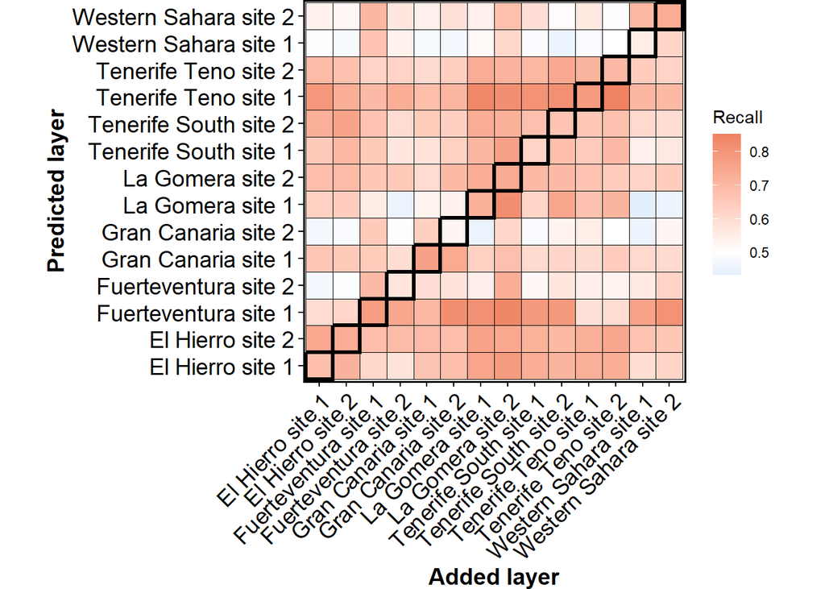

```r
## ---- plot heatmaps ----
site_heatmap_recall <-
  ggplot(result_summary_site, aes(x = train_layer_name, y = test_layer_name, fill = recall)) +
  # First draw the entire heatmap with white borders for all tiles
  geom_tile(color = "black", linewidth = 0.1) +
  # Then draw the diagonal tiles on top with black borders
  geom_tile(data = result_summary_site[result_summary_site$train_layer == result_summary_site$test_layer, ],
            color = "black", linewidth = 1.2) +  # Black borders only for diagonal tiles
  scale_fill_gradient2(low = "steelblue2", mid = "white", high = "salmon2",
                       midpoint = 0.5, na.value = "gray") +  # Set NA values to gray
  labs(x = "Added layer", y = "Predicted layer", fill = "Recall") +
  theme_minimal() +
  theme(
    plot.margin = unit(c(0, 0, 0, 0), "cm"),  # Minimize margins
    panel.background = element_blank(), #This ensures no panel background layers are drawn, which might add extra space.
    panel.grid.major = element_blank(),  # Remove major grid lines
    panel.grid.minor = element_blank(),  # Remove minor grid lines
    axis.text.x = element_text(angle = 45, hjust = 1, vjust = 1)  # Rotate x-axis labels by 45 degrees
  ) +
  coord_fixed() + tme

print(site_heatmap_recall)
```

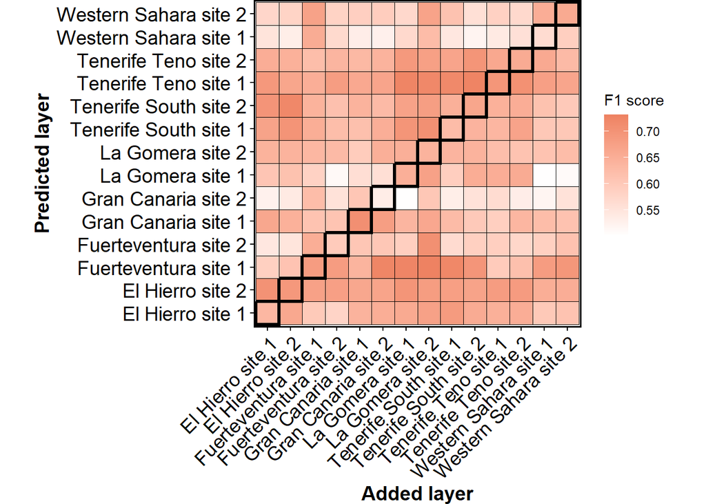

```r
site_heatmap_f1 <-
  ggplot(result_summary_site, aes(x = train_layer_name, y = test_layer_name, fill = f1_score)) +
  # First draw the entire heatmap with white borders for all tiles
  geom_tile(color = "black", linewidth = 0.1) +
  # Then draw the diagonal tiles on top with black borders
  geom_tile(data = result_summary_site[result_summary_site$train_layer == result_summary_site$test_layer, ],
            color = "black", linewidth = 1.2) +  # Black borders only for diagonal tiles
  scale_fill_gradient2(low = "steelblue2", mid = "white", high = "salmon2",
                       midpoint = 0.5, na.value = "gray") +  # Set NA values to gray
  labs(x = "Added layer", y = "Predicted layer", fill = "F1 score") +
  theme_minimal() +
  theme(
    plot.margin = unit(c(0, 0, 0, 0), "cm"),  # Minimize margins
    panel.background = element_blank(), #This ensures no panel background layers are drawn, which might add extra space.
    panel.grid.major = element_blank(),  # Remove major grid lines
    panel.grid.minor = element_blank(),  # Remove minor grid lines
    axis.text.x = element_text(angle = 45, hjust = 1, vjust = 1)  # Rotate x-axis labels by 45 degrees
  ) +
  coord_fixed() + tme

print(site_heatmap_f1)
```

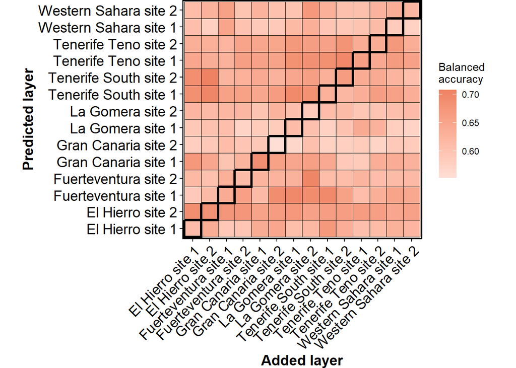

```r
site_heatmap_ba <-
  ggplot(result_summary_site, aes(x = train_layer_name, y = test_layer_name, fill = balanced_accuracy)) +
  # First draw the entire heatmap with white borders for all tiles
  geom_tile(color = "black", linewidth = 0.1) +
  # Then draw the diagonal tiles on top with black borders
  geom_tile(data = result_summary_site[result_summary_site$train_layer == result_summary_site$test_layer, ],
            color = "black", linewidth = 1.2) +  # Black borders only for diagonal tiles
  scale_fill_gradient2(low = "steelblue2", mid = "white", high = "salmon2",
                       midpoint = 0.5, na.value = "gray") +  # Set NA values to gray
  labs(x = "Added layer", y = "Predicted layer", fill = "Balanced \naccuracy") +
  theme_minimal() +
  theme(
    plot.margin = unit(c(0, 0, 0, 0), "cm"),  # Minimize margins
    panel.background = element_blank(), #This ensures no panel background layers are drawn, which might add extra space.
    panel.grid.major = element_blank(),  # Remove major grid lines
    panel.grid.minor = element_blank(),  # Remove minor grid lines
    axis.text.x = element_text(angle = 45, hjust = 1, vjust = 1)  # Rotate x-axis labels by 45 degrees
  ) +
  coord_fixed() + tme

print(site_heatmap_ba)
```

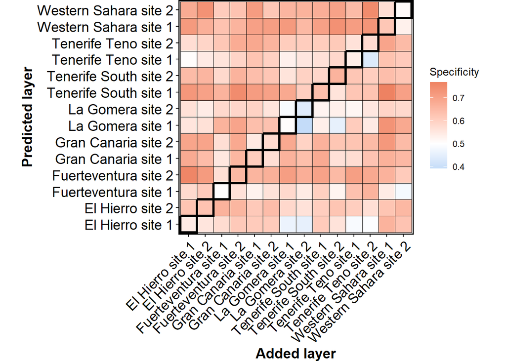

```r
site_heatmap_specificity <-
  ggplot(result_summary_site, aes(x = train_layer_name, y = test_layer_name, fill = specificity)) +
  # First draw the entire heatmap with white borders for all tiles
  geom_tile(color = "black", linewidth = 0.1) +
  # Then draw the diagonal tiles on top with black borders
  geom_tile(data = result_summary_site[result_summary_site$train_layer == result_summary_site$test_layer, ],
            color = "black", linewidth = 1.2) +  # Black borders only for diagonal tiles
  scale_fill_gradient2(low = "steelblue2", mid = "white", high = "salmon2",
                       midpoint = 0.5, na.value = "gray") +  # Set NA values to gray
  labs(x = "Added layer", y = "Predicted layer", fill = "Specificity") +
  theme_minimal() +
  theme(
    plot.margin = unit(c(0, 0, 0, 0), "cm"),  # Minimize margins
    panel.background = element_blank(), #This ensures no panel background layers are drawn, which might add extra space.
    panel.grid.major = element_blank(),  # Remove major grid lines
    panel.grid.minor = element_blank(),  # Remove minor grid lines
    axis.text.x = element_text(angle = 45, hjust = 1, vjust = 1)  # Rotate x-axis labels by 45 degrees
  ) +
  coord_fixed() + tme

print(site_heatmap_specificity)
```

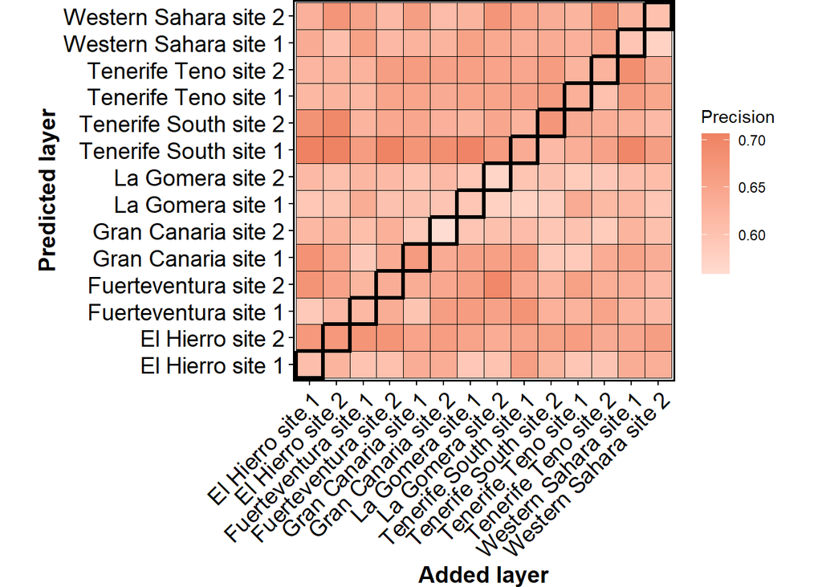

```r
site_heatmap_precision <-
  ggplot(result_summary_site, aes(x = train_layer_name, y = test_layer_name, fill = precision)) +
  # First draw the entire heatmap with white borders for all tiles
  geom_tile(color = "black", linewidth = 0.1) +
  # Then draw the diagonal tiles on top with black borders
  geom_tile(data = result_summary_site[result_summary_site$train_layer == result_summary_site$test_layer, ],
            color = "black", linewidth = 1.2) +  # Black borders only for diagonal tiles
  scale_fill_gradient2(low = "steelblue2", mid = "white", high = "salmon2",
                       midpoint = 0.5, na.value = "gray") +  # Set NA values to gray
  labs(x = "Added layer", y = "Predicted layer", fill = "Precision") +
  theme_minimal() +
  theme(
    plot.margin = unit(c(0, 0, 0, 0), "cm"),  # Minimize margins
    panel.background = element_blank(), #This ensures no panel background layers are drawn, which might add extra space.
    panel.grid.major = element_blank(),  # Remove major grid lines
    panel.grid.minor = element_blank(),  # Remove minor grid lines
    axis.text.x = element_text(angle = 45, hjust = 1, vjust = 1)  # Rotate x-axis labels by 45 degrees
  ) +
  coord_fixed() + tme

print(site_heatmap_precision)
```

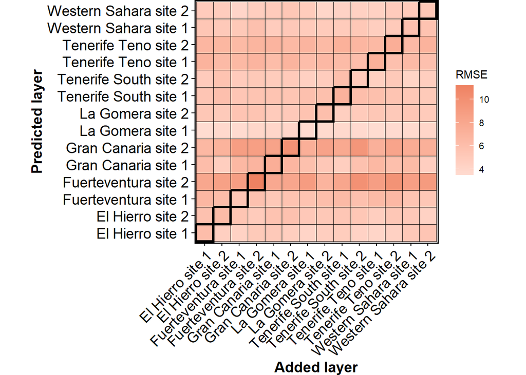

```r
site_heatmap_rmse <-
  ggplot(result_summary_site, aes(x = train_layer_name, y = test_layer_name, fill = rmse)) +
  # First draw the entire heatmap with white borders for all tiles
  geom_tile(color = "black", linewidth = 0.1) +
  # Then draw the diagonal tiles on top with black borders
  geom_tile(data = result_summary_site[result_summary_site$train_layer == result_summary_site$test_layer, ],
            color = "black", linewidth = 1.2) +  # Black borders only for diagonal tiles
  scale_fill_gradient2(low = "steelblue2", mid = "white", high = "salmon2",
                       midpoint = 0.5, na.value = "gray") +  # Set NA values to gray
  labs(x = "Added layer", y = "Predicted layer", fill = "RMSE") +
  theme_minimal() +
  theme(
    plot.margin = unit(c(0, 0, 0, 0), "cm"),  # Minimize margins
    panel.background = element_blank(), #This ensures no panel background layers are drawn, which might add extra space.
    panel.grid.major = element_blank(),  # Remove major grid lines
    panel.grid.minor = element_blank(),  # Remove minor grid lines
    axis.text.x = element_text(angle = 45, hjust = 1, vjust = 1)  # Rotate x-axis labels by 45 degrees
  ) +
  coord_fixed() + tme

print(site_heatmap_rmse)
```

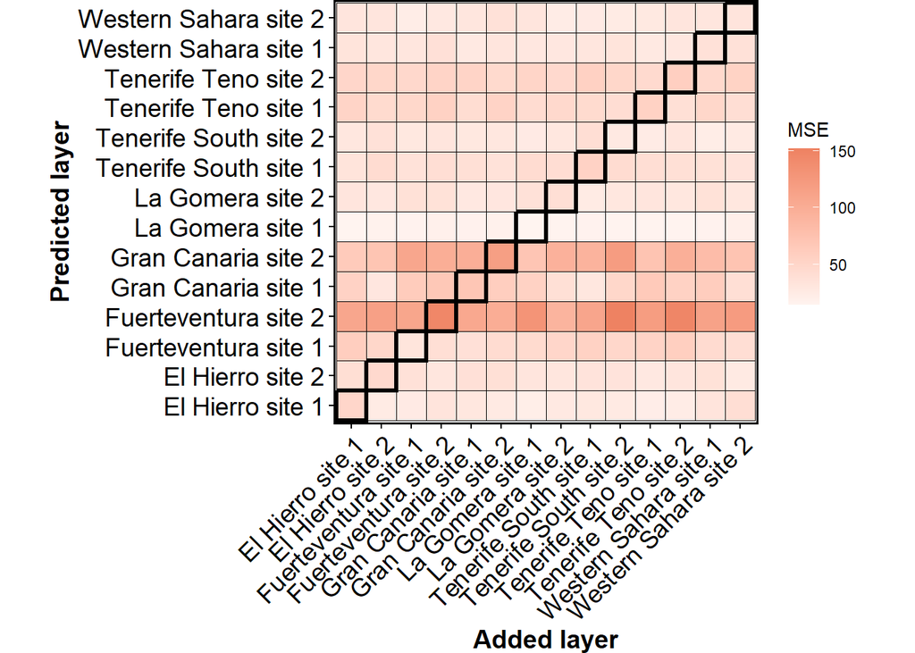

```r
site_heatmap_mse <-
  ggplot(result_summary_site, aes(x = train_layer_name, y = test_layer_name, fill = mse)) +
  # First draw the entire heatmap with white borders for all tiles
  geom_tile(color = "black", linewidth = 0.1) +
  # Then draw the diagonal tiles on top with black borders
  geom_tile(data = result_summary_site[result_summary_site$train_layer == result_summary_site$test_layer, ],
            color = "black", linewidth = 1.2) +  # Black borders only for diagonal tiles
  scale_fill_gradient2(low = "steelblue2", mid = "white", high = "salmon2",
                       midpoint = 0.5, na.value = "gray") +  # Set NA values to gray
  labs(x = "Added layer", y = "Predicted layer", fill = "MSE") +
  theme_minimal() +
  theme(
    plot.margin = unit(c(0, 0, 0, 0), "cm"),  # Minimize margins
    panel.background = element_blank(), #This ensures no panel background layers are drawn, which might add extra space.
    panel.grid.major = element_blank(),  # Remove major grid lines
    panel.grid.minor = element_blank(),  # Remove minor grid lines
    axis.text.x = element_text(angle = 45, hjust = 1, vjust = 1)  # Rotate x-axis labels by 45 degrees
  ) +
  coord_fixed() + tme

print(site_heatmap_mse)
```

```r
# make_heatmap_plot <- function(data,            # Main data frame for the heatmap
#                               eval_col,        # Evaluator column name (e.g., "recall")
#                               train_col = "train_layer_name",  # x-axis variable name
#                               test_col = "test_layer_name",    # y-axis variable name
#                               x_lab = "Added layer",           # x-axis label
#                               y_lab = "Predicted layer",       # y-axis label
#                               fill_lab = NULL,                 # Fill legend label; if NULL, defaults to eval_col
#                               low = "steelblue2",
#                               mid = "white",
#                               high = "salmon2",
#                               midpoint = 0.5,
#                               na_value = "gray",
#                               extra_theme = NULL) {            # Additional theme modifications (e.g., tme)
#
#   # If no fill legend label is provided, use the evaluator name
#   if (is.null(fill_lab)) {
#     fill_lab <- eval_col
#   }
#
#   # # If no diagonal data frame is provided, subset the main data where training and testing layers match.
#   # if (is.null(diag_data)) {
#   #   diag_data <- data[data[[train_col]] == data[[test_col]], ]
#   # }
#
#   # Create the heatmap
#   p <- ggplot(data, aes_string(x = train_col, y = test_col, fill = eval_col)) +
#     # First draw all tiles with thin black borders
#     geom_tile(color = "black", linewidth = 0.1) +
#     # Overlay the diagonal tiles (using the provided or derived data) with thicker black borders
#     geom_tile(data = diag_data, aes_string(x = train_col, y = test_col, fill = eval_col),
#               color = "black", linewidth = 1.2) +
#     # Define the fill gradient and set NA color
#     scale_fill_gradient2(low = low, mid = mid, high = high,
#                          midpoint = midpoint, na.value = na_value) +
#     # Add axis and legend labels
#     labs(x = x_lab, y = y_lab, fill = fill_lab) +
#     theme_minimal() +
#     theme(
#       plot.margin = unit(c(0, 0, 0, 0), "cm"),  # Minimize margins
#       panel.background = element_blank(),       # Remove panel background
#       panel.grid.major = element_blank(),       # Remove major grid lines
#       panel.grid.minor = element_blank(),       # Remove minor grid lines
#       axis.text.x = element_text(angle = 45, hjust = 1, vjust = 1)  # Rotate x-axis labels
#     ) +
#     coord_fixed() + tme
#
#   return(p)
# }

# For an evaluator "recall" on a data frame 'result_summary_island'
# (assuming tme is a predefined ggplot theme you want to apply)
# site_heatmap_ba <- make_heatmap_plot(data = result_summary_site,
#                                            eval_col = "balanced_accuracy",
#                                            train_col = "train_layer_name",
#                                            test_col = "test_layer_name",
#                                            x_lab = "Added layer",
#                                            y_lab = "Predicted layer",
#                                            fill_lab = "Balanced \naccuracy",
#                                            extra_theme = tme)
#
# site_heatmap_f1 <- make_heatmap_plot(data = result_summary_site,
#                                        eval_col = "f1_score",
#                                        train_col = "train_layer_name",
#                                        test_col = "test_layer_name",
#                                        x_lab = "Added layer",
#                                        y_lab = "Predicted layer",
#                                        fill_lab = "F1 score",
#                                        extra_theme = tme)
#
# site_heatmap_recall <- make_heatmap_plot(data = result_summary_site,
#                                            eval_col = "recall",
#                                            train_col = "train_layer_name",
#                                            test_col = "test_layer_name",
#                                            x_lab = "Added layer",
#                                            y_lab = "Predicted layer",
#                                            fill_lab = "Recall",
#                                            extra_theme = tme)
#
# site_heatmap_precision <- make_heatmap_plot(data = result_summary_site,
#                                            eval_col = "precision",
#                                            train_col = "train_layer_name",
#                                            test_col = "test_layer_name",
#                                            x_lab = "Added layer",
#                                            y_lab = "Predicted layer",
#                                            fill_lab = "Precision",
#                                            extra_theme = tme)
#
# site_heatmap_specificity <- make_heatmap_plot(data = result_summary_site,
#                                               eval_col = "specificity",
#                                               train_col = "train_layer_name",
#                                               test_col = "test_layer_name",
#                                               x_lab = "Added layer",
#                                               y_lab = "Predicted layer",
#                                               fill_lab = "Specificity",
#                                               extra_theme = tme)
#
# p1 <- site_heatmap_f1 +
#   theme(legend.position = "none",
#         axis.title.y = element_blank(),
#         plot.margin = unit(c(0.5, 0.5, 0.1, 0.3), "cm"))
#
# p2 <- site_heatmap_ba +
#   theme(legend.position = "none",
#         axis.title.y = element_blank(),
#         plot.margin = unit(c(0.5, 0.5, 0.1, 0.3), "cm"))
#
# p3 <- site_heatmap_recall +
#   theme(legend.position = "none",
#         axis.title.y = element_blank(),
#         plot.margin = unit(c(0.5, 0.5, 0.1, 0.3), "cm"))
#
# p4 <- site_heatmap_precision +
#   theme(legend.position = "none",
#         axis.title.y = element_blank(),
#         plot.margin = unit(c(0.5, 0.5, 0.1, 0.3), "cm"))
#
# p5 <- site_heatmap_specificity +
#   theme(legend.position = "none",
#         axis.title.y = element_blank(),
#         plot.margin = unit(c(0.5, 0.5, 0.1, 0.3), "cm"))
#
# combined_plots <- arrangeGrob(
#   p1, p2, p3, p4, p5,
#   ncol = 3,
#   nrow = 2
# )
# combined_with_axes <- arrangeGrob(
#   combined_plots,
#   #bottom = textGrob("F1 score", gp = gpar(fontsize = 14, fontface = "bold"), vjust = -1.5),
#   left   = textGrob("Predicted location", rot = 90, gp = gpar(fontsize = 14, fontface = "bold"))
# )
#
# final_plot <- grid.arrange(
#   combined_with_axes,
#   ncol = 3,
#   widths = c(2, 0.3, 0.3)
# )
## ---- compare scales ----
# make a long list
# df1_labeled <- result_summary_site %>%
#   mutate(scale = "Site")
#
# df2_labeled <- result_summary_island %>%
#   mutate(scale = "Island")
#
# df_combined <- bind_rows(df1_labeled, df2_labeled)
#
# df_long <- df_combined %>%
#   pivot_longer(
#     cols = c("f1_score", "recall", "precision", "balanced_accuracy", "mcc", "specificity"),
#     names_to = "metric",
#     values_to = "value"
#   )
#
# metrics <- c("f1_score", "recall", "precision", "balanced_accuracy", "mcc", "specificity")
#
# results <- lapply(metrics, function(metric) {
#   test_normality_site <- shapiro.test(result_summary_site[[metric]])$p.value
#   test_normality_island <- shapiro.test(result_summary_island[[metric]])$p.value
#
#   if (test_normality_site > 0.05 & test_normality_island > 0.05) {
#     test <- t.test(result_summary_site[[metric]], result_summary_island[[metric]], var.equal = FALSE)
#   } else {
#     test <- wilcox.test(result_summary_site[[metric]], result_summary_island[[metric]])
#   }
#
#   data.frame(
#     Metric = metric,
#     Test = ifelse(test_normality_site > 0.05 & test_normality_island > 0.05, "T-test", "Wilcoxon"),
#     P_value = test$p.value
#   )
# })
#
# results_df <- do.call(rbind, results)
# print(results_df)
#
# # Define significance function
# get_pvalue_asterisks <- function(p) {
#   if (p < 0.001) return("***")  # Highly significant
#   else if (p < 0.01) return("**")  # Very significant
#   else if (p < 0.05) return("*")  # Significant
#   else return("ns")  # Not significant
# }
#
# stat_results <- lapply(metrics, function(metric) {
#   data_metric <- df_long %>% filter(metric == !!metric)  # Filter for the specific metric
#
#   test <- t.test(value ~ scale, data = data_metric)  # Perform t-test
#
#   p_value <- test$p.value
#   significance <- get_pvalue_asterisks(p_value)
#
#   data.frame(
#     metric = metric,
#     p_value = p_value,
#     significance = significance
#   )
# })
#
# stat_results_df <- do.call(rbind, stat_results)
#
# # Merge significance levels with the dataset
# df_long <- df_long %>%
#   left_join(stat_results_df, by = "metric")
#
# # Create the boxplot with significance annotations
# ggplot(df_long, aes(x = metric, y = value, fill = scale)) +
#   geom_boxplot(notch = TRUE, position = position_dodge(width = 0.8)) +
#   theme_minimal() +
#   labs(title = "Comparison of Performance", x = "Metric", y = "Value") +
#   scale_fill_manual(values = c("Site" = "lightsteelblue2", "Island" = "wheat2")) +  # Custom colors
#   scale_x_discrete(labels = c(
#     "f1_score" = "F1 score",
#     "recall" = "Recall",
#     "precision" = "Precision",
#     "balanced_accuracy" = "Balanced \naccuracy",
#     "mcc" = "MCC",
#     "specificity" = "Specificity"
#   )) +  # Properly formatted labels
#   stat_compare_means(aes(group = scale), method = "t.test", label = "p.signif",
#                      label.y = max(df_long$value, na.rm = TRUE) + 0.05,
#                      size = 5)  +
#   theme(legend.text = element_text(size = 14),
#         legend.title = element_text(size = 14), ) + tme
#
# ## repeat seperately for rmse and mse
# df_long <- df_combined %>%
#   pivot_longer(
#     cols = c("rmse", "mse"),
#     names_to = "metric",
#     values_to = "value"
#   )
#
# metrics <- c("rmse", "mse")
#
# results <- lapply(metrics, function(metric) {
#   test_normality_site <- shapiro.test(result_summary_site[[metric]])$p.value
#   test_normality_island <- shapiro.test(result_summary_island[[metric]])$p.value
#
#   if (test_normality_site > 0.05 & test_normality_island > 0.05) {
#     test <- t.test(result_summary_site[[metric]], result_summary_island[[metric]], var.equal = FALSE)
#   } else {
#     test <- wilcox.test(result_summary_site[[metric]], result_summary_island[[metric]])
#   }
#
#   data.frame(
#     Metric = metric,
#     Test = ifelse(test_normality_site > 0.05 & test_normality_island > 0.05, "T-test", "Wilcoxon"),
#     P_value = test$p.value
#   )
# })
#
# results_df <- do.call(rbind, results)
# print(results_df)
#
# # Define significance function
# get_pvalue_asterisks <- function(p) {
#   if (p < 0.001) return("***")  # Highly significant
#   else if (p < 0.01) return("**")  # Very significant
#   else if (p < 0.05) return("*")  # Significant
#   else return("ns")  # Not significant
# }
#
# stat_results <- lapply(metrics, function(metric) {
#   data_metric <- df_long %>% filter(metric == !!metric)  # Filter for the specific metric
#
#   test <- t.test(value ~ scale, data = data_metric)  # Perform t-test
#
#   p_value <- test$p.value
#   significance <- get_pvalue_asterisks(p_value)
#
#   data.frame(
#     metric = metric,
#     p_value = p_value,
#     significance = significance
#   )
# })
#
# stat_results_df <- do.call(rbind, stat_results)
#
# # Merge significance levels with the dataset
# df_long <- df_long %>%
#   left_join(stat_results_df, by = "metric")
#
# # Create the boxplot with significance annotations
# ggplot(df_long, aes(x = metric, y = value, fill = scale)) +
#   geom_boxplot(notch = TRUE, position = position_dodge(width = 0.8)) +
#   theme_minimal() +
#   labs(title = "Comparison of Performance", x = "Metric", y = "Value") +
```

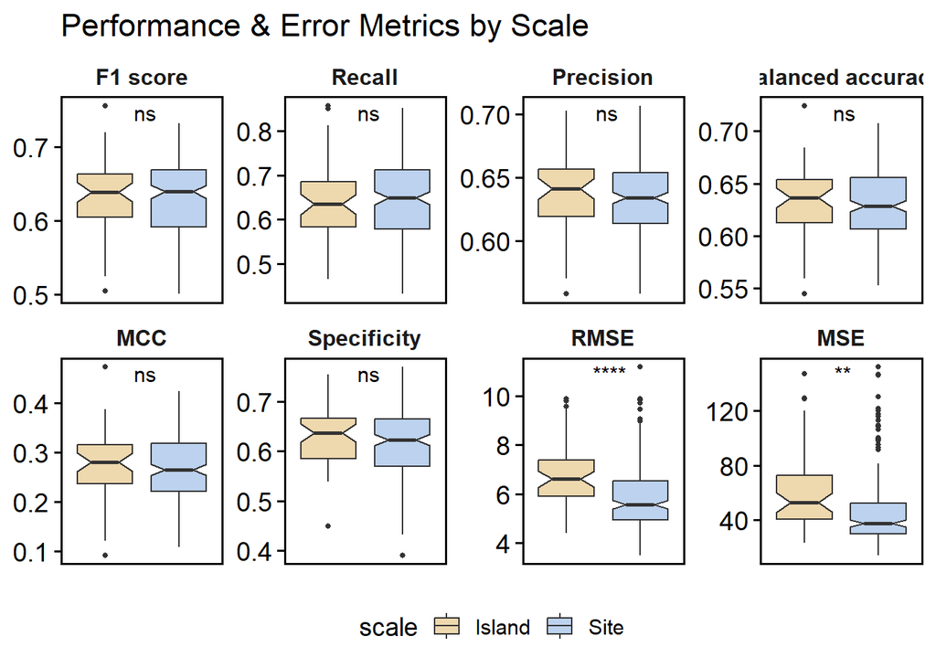

```r
#   scale_fill_manual(values = c("Site" = "lightsteelblue2", "Island" = "wheat2")) +  # Custom colors
#   scale_x_discrete(labels = c(
#     "rmse" = "RMSE",
#     "mse" = "MSE"
#   )) +  # Properly formatted labels
#   stat_compare_means(aes(group = scale), method = "t.test", label = "p.signif",
#                      label.y = max(df_long$value, na.rm = TRUE) + 0.05,
#                      size = 5)  +
#   theme(legend.text = element_text(size = 14),
#         legend.title = element_text(size = 14), ) + tme


# 1. Combine + pivot (adding rmse & mse) and force the order you want:
df_long <- bind_rows(
  result_summary_site   %>% mutate(scale = "Site"),
  result_summary_island %>% mutate(scale = "Island")
) %>%
  pivot_longer(
    cols      = c("f1_score","recall","precision",
                  "balanced_accuracy","mcc","specificity",
                  "rmse","mse"),
    names_to  = "metric",
    values_to = "value"
  ) %>%
  mutate(metric = factor(metric, levels = c(
    "f1_score","recall","precision","balanced_accuracy",
    "mcc","specificity","rmse","mse"
  )))

# 2. Pretty facet titles with units:
metric_labels <- c(
  f1_score          = "F1 score",
  recall            = "Recall",
  precision         = "Precision",
  balanced_accuracy = "Balanced accuracy",
  mcc               = "MCC",
  specificity       = "Specificity",
  rmse              = "RMSE",
  mse               = "MSE"
)

# 3. Plot with free_y, custom labels, and centered stars at the top:
ggplot(df_long, aes(x = scale, y = value, fill = scale)) +
  geom_boxplot(
    notch        = TRUE,
    outlier.size = 1,
    position     = position_dodge(width = 0.75)
  ) +
  facet_wrap(
    ~ metric,
    scales   = "free_y",
    labeller = as_labeller(metric_labels),
    ncol     = 4
  ) +
  stat_compare_means(
    method    = "t.test",
    label     = "p.signif",
    # put label at the very top of each facet:
    label.y   = Inf,
    vjust     = 1.5,
    # center between the two boxes (position 1 & 2):
    label.x   = 1.45,
    tip.length= 0.01,
    size      = 4
  ) +
  scale_fill_manual(values = c("Site" = "lightsteelblue2",
                               "Island" = "wheat2")) +
  labs(
    title = "Performance & Error Metrics by Scale",
    x     = NULL,
    y     = NULL
  ) +
  theme_minimal(base_size = 14) +
  theme(
    strip.text      = element_text(face = "bold", size = 12),
    axis.text.x     = element_blank(),
    axis.ticks.x    = element_blank(),
    legend.position = "bottom"
  ) + tme
```

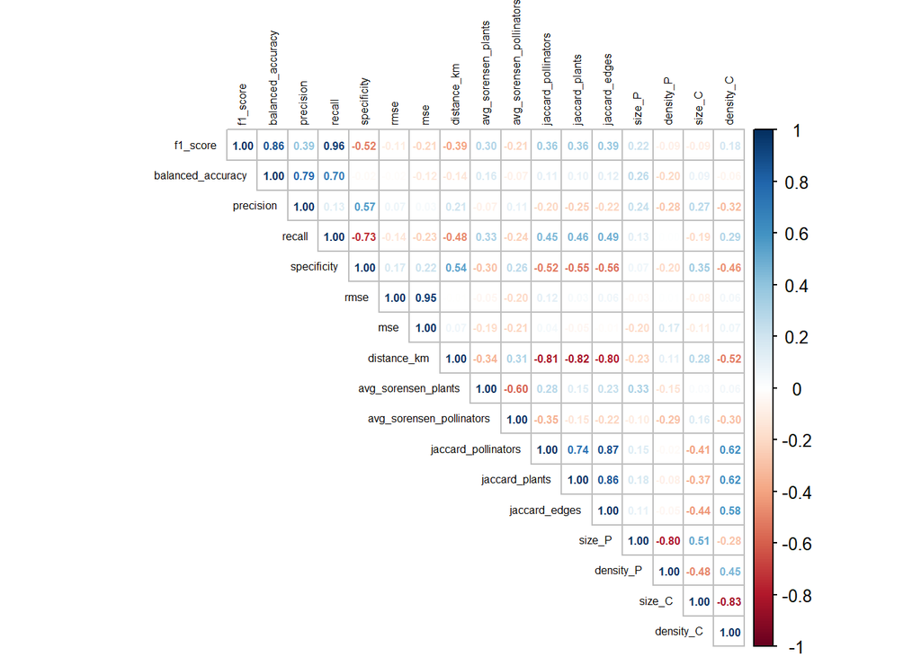

```r
## ---- variable importance ----
# analyze only one off-diagonal
df_off <- result_summary_site %>%
  # Keep rows where train_layer < test_layer (upper triangle) or on the diagonal
  filter(train_layer != test_layer)
# subset relavant columns
df_subset_cor <- df_off %>% select(f1_score, balanced_accuracy, precision, recall, specificity, rmse, mse, distance_km, avg_sorensen_plants,    avg_sorensen_pollinators,   jaccard_pollinators,    jaccard_plants, jaccard_edges, size_P,  density_P, size_C,  density_C)

### ---- autocorrelation check ----
# 2. Compute correlation matrix
cor_mat <- cor(df_subset_cor, use = "complete.obs")
#write.csv(cor_mat, "island_autocorrelation.csv")

# 3. Visualize (optional)

corrplot(cor_mat,
         method = "number",      # or "circle", "color", etc.
         type = "upper",         # upper/lower/full
         tl.cex = 0.5,           # text label size
         number.cex = 0.5,       # correlation coefficient size
         tl.col = "black"       # text label color (optional)
)
```

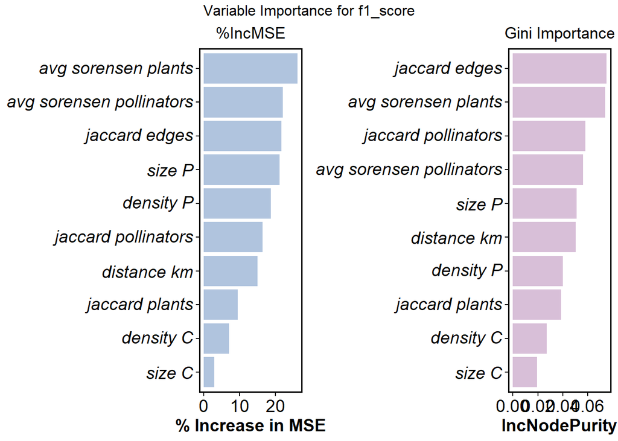

```r
# ### ---- linear regression ----
# # Fit a linear model predicting f1_score from all other numeric predictors
# lm_fit <- lm(f1_score ~ distance_km + avg_sorensen_plants +   avg_sorensen_pollinators +  jaccard_pollinators +   jaccard_plants +    jaccard_edges + size_P +    density_P + size_C +    density_C,
#              data = df_subset)
#
# summary(lm_fit)
#
# # Random Forest (only with numeric columns)
# rf_fit <- randomForest(f1_score ~ ., data = df_subset, importance = TRUE)
#
# # Check variable importance
# importance(rf_fit)
# varImpPlot(rf_fit)
#
# # Extract importance
# imp <- importance(rf_fit)
# # For regression: imp is a matrix with columns: %IncMSE, IncNodePurity
# # For classification: imp often has two columns per measure.
# # We'll assume %IncMSE and IncNodePurity are present.
#
# # Turn it into a data frame for easier plotting
# imp_df <- as.data.frame(imp)
# imp_df$f1_score <- rownames(imp_df)  # Keep variable names in a column
#
# # Example for %IncMSE
# ggplot(imp_df, aes(x = reorder(f1_score, `%IncMSE`), y = `%IncMSE`)) +
#   geom_bar(stat = "identity", fill = "lightsteelblue") +
#   coord_flip() +
#   labs(x = "F1 score",
#        y = "% Increase in MSE") +
#   theme_minimal() + tme +
#   scale_x_discrete(labels = function(x) lapply(strsplit(x, "_"), function(y) {
#     bquote(italic(.(paste(y, collapse = " "))))
#   })) +
#   scale_y_discrete(labels = function(x) lapply(strsplit(x, "_"), function(y) {
#     bquote(italic(.(paste(y, collapse = " "))))
#   }))

plot_rf_importance <- function(df_off, response_var, tme) {

  # Step 1: Select predictors + the response variable
  predictors <- c("distance_km", "avg_sorensen_plants", "avg_sorensen_pollinators",
                  "jaccard_pollinators", "jaccard_plants", "jaccard_edges",
                  "size_P", "density_P", "size_C", "density_C")

  df_subset <- df_off %>% select(all_of(c(response_var, predictors)))

  # Step 2: Fit Random Forest
  rf_fit <- randomForest(
    formula = as.formula(paste(response_var, "~ .")),
    data = df_subset,
    importance = TRUE
  )

  # Step 3: Extract and prepare importance data
  imp_df <- as.data.frame(importance(rf_fit))
  imp_df$variable <- rownames(imp_df)

  # Plot 1: %IncMSE
  plot_incMSE <- ggplot(imp_df, aes(x = reorder(variable, `%IncMSE`), y = `%IncMSE`)) +
    geom_bar(stat = "identity", fill = "lightsteelblue") +
    coord_flip() +
    labs(title = "%IncMSE", x = NULL, y = "% Increase in MSE") +
    theme_minimal() + tme +
    theme(plot.title = element_text(hjust = 0.5)) +
    scale_x_discrete(labels = function(x) lapply(strsplit(x, "_"), function(y) {
      bquote(italic(.(paste(y, collapse = " "))))
    }))

  # Plot 2: IncNodePurity (Gini importance)
  plot_gini <- ggplot(imp_df, aes(x = reorder(variable, IncNodePurity), y = IncNodePurity)) +
    geom_bar(stat = "identity", fill = "thistle") +
    coord_flip() +
    labs(title = "Gini Importance", x = NULL, y = "IncNodePurity") +
    theme_minimal() + tme +
    theme(plot.title = element_text(hjust = 0.5)) +
    scale_x_discrete(labels = function(x) lapply(strsplit(x, "_"), function(y) {
      bquote(italic(.(paste(y, collapse = " "))))
    }))

  # Combine both plots side by side
  combined_plot <- grid.arrange(
    plot_incMSE,
    plot_gini,
    ncol = 2,
    top = paste("Variable Importance for", response_var)
  )

  return(combined_plot)
}

plot_rf_importance(df_off, "f1_score", tme)
```

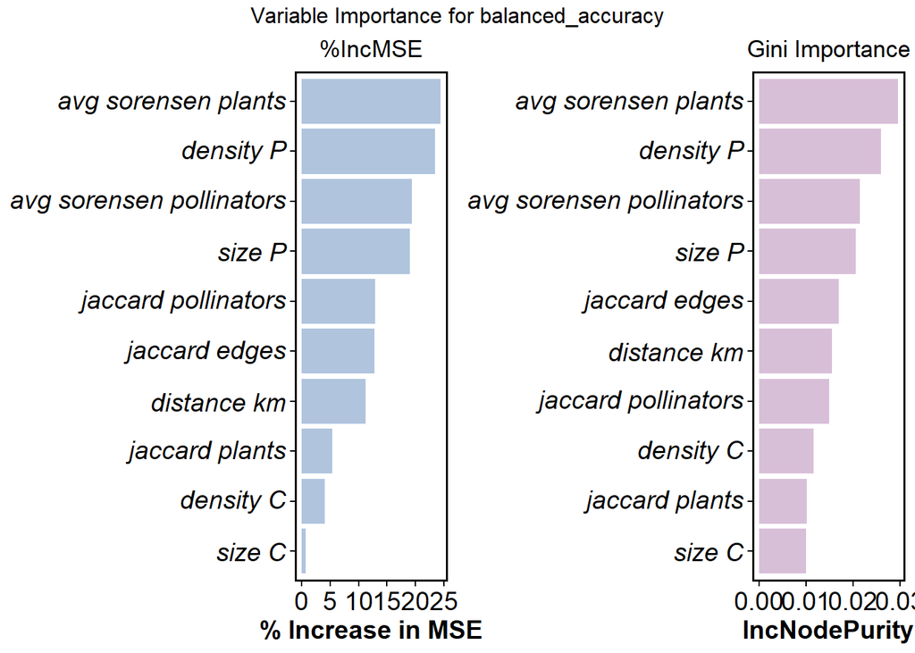

```r
plot_rf_importance(df_off, "balanced_accuracy", tme)
```

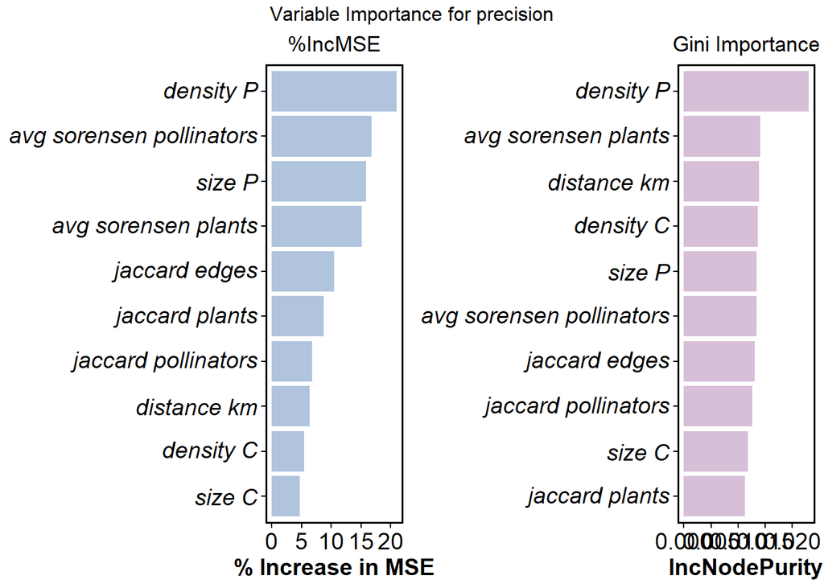

```r
plot_rf_importance(df_off, "precision", tme)
```

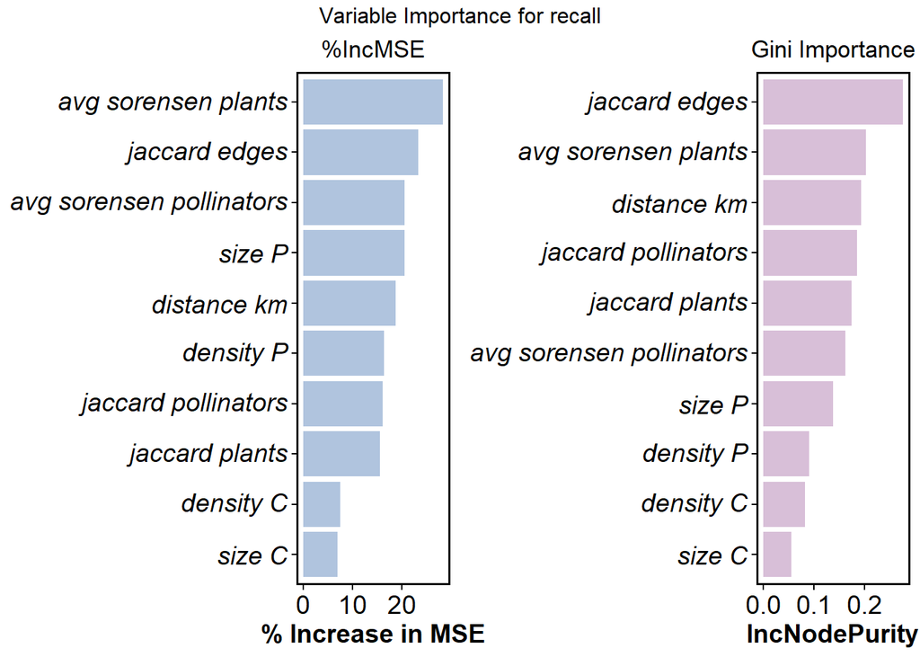

```r
plot_rf_importance(df_off, "recall", tme)
```

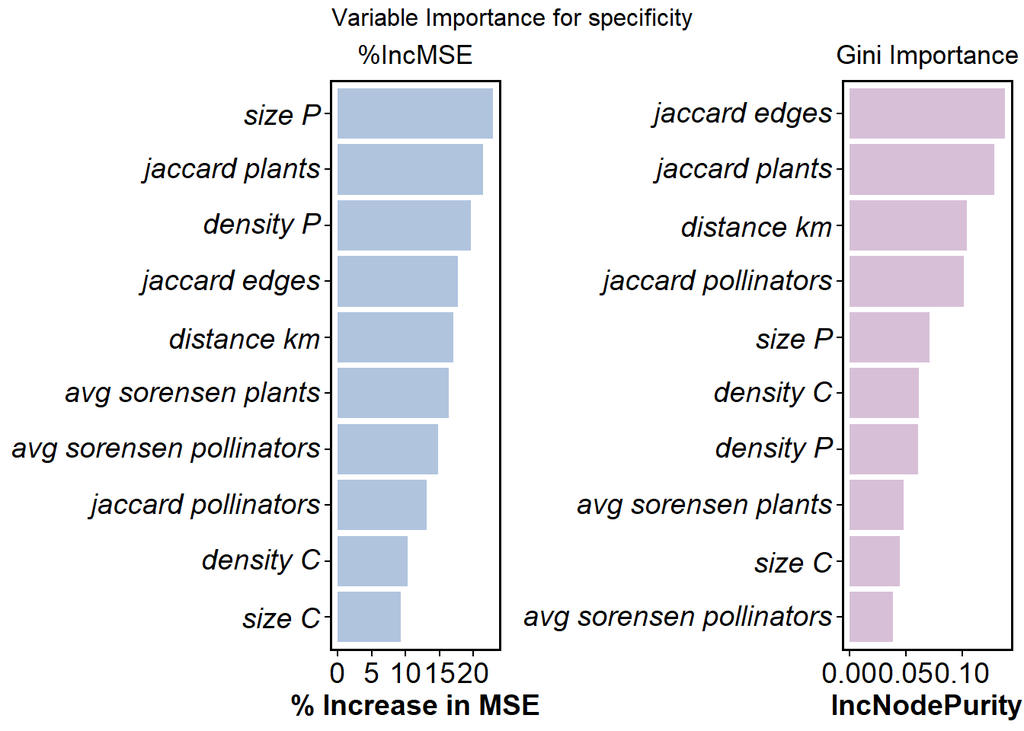

```r
plot_rf_importance(df_off, "specificity", tme)
```

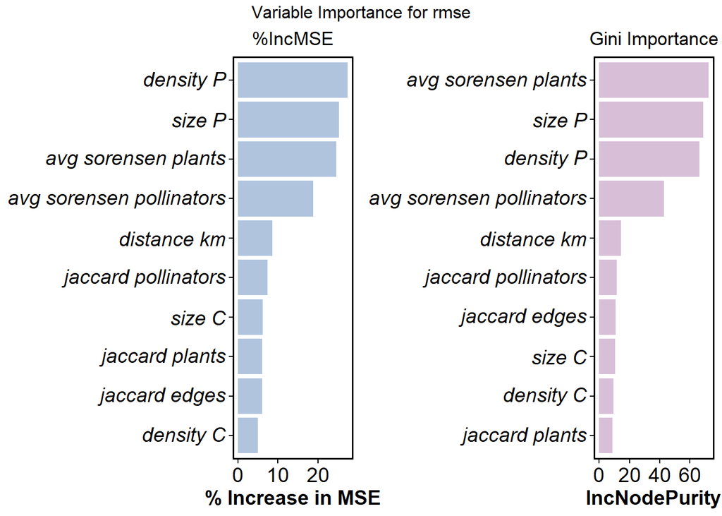

```r
plot_rf_importance(df_off, "rmse", tme)
```

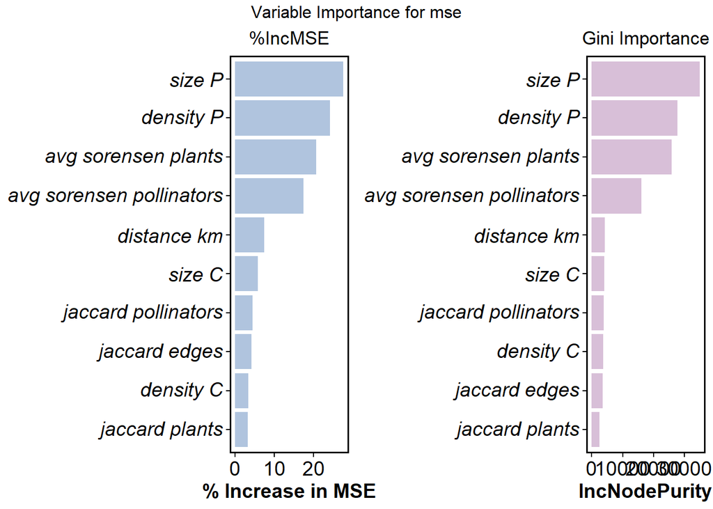

```r
plot_rf_importance(df_off, "mse", tme)
```

```r
### ---- table of variable importance ----

summarize_rf_importance_and_correlation <- function(df_off, response_var) {

  predictors <- c("distance_km", "avg_sorensen_plants", "avg_sorensen_pollinators",
                  "jaccard_pollinators", "jaccard_plants", "jaccard_edges",
                  "size_P", "density_P", "size_C", "density_C")

  df_subset <- df_off %>% select(all_of(c(response_var, predictors)))

  rf_fit <- randomForest(
    formula = as.formula(paste(response_var, "~ .")),
    data = df_subset,
    importance = TRUE
  )

  imp_df <- as.data.frame(importance(rf_fit)) %>%
    tibble::rownames_to_column("variable") %>%
    rename(IncMSE = `%IncMSE`, IncNodePurity = IncNodePurity)

  cor_results <- lapply(predictors, function(var) {
    test <- cor.test(df_subset[[var]], df_subset[[response_var]])
    data.frame(
      variable = var,
      correlation = test$estimate,
      p_value = test$p.value,
      significance = case_when(
        test$p.value < 0.001 ~ "***",
        test$p.value < 0.01 ~ "**",
        test$p.value < 0.05 ~ "*",
        test$p.value < 0.1 ~ ".",
        TRUE ~ ""
      )
    )
  }) %>% bind_rows()

  result_table <- left_join(imp_df, cor_results, by = "variable") %>%
    mutate(evaluator = response_var) %>%
    select(variable, evaluator, everything()) %>%
    arrange(desc(IncMSE))

  return(result_table)
}

# Assuming your data is in df_off and you want to analyze "f1_score":
result_f1 <- summarize_rf_importance_and_correlation(df_off, "f1_score")

# View the table
print(result_f1)
```

```
##                    variable evaluator    IncMSE IncNodePurity correlation
## 1       avg_sorensen_plants  f1_score 26.023714    0.07332272  0.29509884
## 2             jaccard_edges  f1_score 21.603589    0.07521296  0.38510626
## 3  avg_sorensen_pollinators  f1_score 20.573241    0.05694777 -0.21198339
## 4                 density_P  f1_score 19.675408    0.04155994 -0.08987088
## 5                    size_P  f1_score 19.150302    0.04514140  0.21759355
## 6       jaccard_pollinators  f1_score 16.214286    0.05785375  0.36454912
## 7               distance_km  f1_score 15.073733    0.05309425 -0.39036072
## 8            jaccard_plants  f1_score 10.229239    0.03657943  0.36223187
## 9                 density_C  f1_score  5.963322    0.02770460  0.18439150
## 10                   size_C  f1_score  4.886980    0.02063907 -0.09201548
##         p_value significance
## 1  5.252368e-05          ***
## 2  7.958548e-08          ***
## 3  4.068117e-03           **
## 4  2.276194e-01
## 5  3.170442e-03           **
## 6  4.206919e-07          ***
## 7  5.103621e-08          ***
## 8  5.039392e-07          ***
## 9  1.270823e-02            *
## 10 2.166718e-01
```

```r
# several evaluators
evaluators <- c("f1_score", "balanced_accuracy", "precision", "recall", "specificity", "mcc", "rmse", "mse")

summary_all <- bind_rows(lapply(evaluators, function(ev) {
  summarize_rf_importance_and_correlation(df_off, ev)
}))


# # for both scales
# summary_island <- summary_all %>% mutate(scale = "island")
#
# df_offs_site <- result_summary_site %>% filter(train_layer != test_layer)
#
# summary_site <- bind_rows(lapply(evaluators, function(ev) {
#   summarize_rf_importance_and_correlation(df_offs_site, ev)
# })) %>% mutate(scale = "site") # fix to have all variables

# summary_all_scales <- bind_rows(summary_island, summary_site)
library(knitr)
library(kableExtra)
summary_all %>%
  mutate(
    correlation_fmt = ifelse(
      significance != "",
      cell_spec(round(correlation, 3), bold = TRUE,
                color = ifelse(correlation > 0, "salmon", "lightsteelblue")),
      cell_spec(round(correlation, 3), color = ifelse(correlation > 0, "red", "blue"))
    ),
    p_value = round(p_value, 3),
    IncMSE = round(IncMSE, 3),
    IncNodePurity = round(IncNodePurity, 3)
  ) %>%
  select(variable, evaluator, IncMSE, IncNodePurity, correlation_fmt, p_value, significance) %>%
  kable("html", escape = FALSE, col.names = c(
    "Variable", "Evaluator", "%IncMSE", "Gini", "Correlation", "P-value", "Sig."
  )) %>%
  kable_styling(full_width = FALSE, position = "left")
```

Variable

Evaluator

%IncMSE

Gini

Correlation

P-value

Sig.

avg_sorensen_plants

f1_score

26.702

0.072

0.295

0.000

***

avg_sorensen_pollinators

f1_score

20.843

0.057

-0.212

0.004

jaccard_edges

f1_score

20.725

0.076

0.385

0.000

***

size_P

f1_score

19.836

0.049

0.218

0.003

density_P

f1_score

17.704

0.042

-0.09

0.228

distance_km

f1_score

15.614

0.051

-0.39

0.000

***

jaccard_pollinators

f1_score

14.402

0.057

0.365

0.000

***

jaccard_plants

f1_score

9.012

0.040

0.362

0.000

***

density_C

f1_score

6.004

0.026

0.184

0.013

size_C

f1_score

3.591

0.018

-0.092

0.217

avg_sorensen_plants

balanced_accuracy

22.954

0.028

0.163

0.028

density_P

balanced_accuracy

21.194

0.025

-0.202

0.006

avg_sorensen_pollinators

balanced_accuracy

20.401

0.023

-0.075

0.315

size_P

balanced_accuracy

17.704

0.019

0.262

0.000

***

jaccard_edges

balanced_accuracy

13.343

0.017

0.125

0.094

.

jaccard_pollinators

balanced_accuracy

12.854

0.016

0.112

0.131

distance_km

balanced_accuracy

11.591

0.016

-0.136

0.066

.

jaccard_plants

balanced_accuracy

4.279

0.010

0.096

0.198

density_C

balanced_accuracy

3.207

0.011

-0.056

0.455

size_C

balanced_accuracy

2.088

0.010

0.087

0.241

density_P

precision

22.096

0.023

-0.279

0.000

***

avg_sorensen_pollinators

precision

18.121

0.014

0.108

0.147

avg_sorensen_plants

precision

14.930

0.013

-0.073

0.329

size_P

precision

13.666

0.013

0.237

0.001

jaccard_edges

precision

9.702

0.013

-0.218

0.003

distance_km

precision

6.991

0.015

0.205

0.005

jaccard_plants

precision

6.026

0.011

-0.249

0.001

***

jaccard_pollinators

precision

5.810

0.013

-0.204

0.006

size_C

precision

2.316

0.012

0.273

0.000

***

density_C

precision

2.237

0.014

-0.317

0.000

***

avg_sorensen_plants

recall

26.898

0.201

0.326

0.000

***

jaccard_edges

recall

23.801

0.290

0.487

0.000

***

avg_sorensen_pollinators

recall

20.775

0.165

-0.24

0.001

size_P

recall

19.520

0.140

0.129

0.083

.

distance_km

recall

19.093

0.201

-0.478

0.000

***

density_P

recall

17.253

0.098

0.003

0.965

jaccard_pollinators

recall

15.613

0.173

0.45

0.000

***

jaccard_plants

recall

14.472

0.173

0.461

0.000

***

density_C

recall

8.108

0.079

0.291

0.000

***

size_C

recall

6.712

0.055

-0.192

0.009

size_P

specificity

24.449

0.073

0.068

0.361

jaccard_plants

specificity

22.231

0.138

-0.552

0.000

***

density_P

specificity

19.989

0.058

-0.196

0.008

avg_sorensen_plants

specificity

18.258

0.047

-0.299

0.000

***

jaccard_edges

specificity

17.747

0.134

-0.56

0.000

***

distance_km

specificity

16.288

0.096

0.536

0.000

***

jaccard_pollinators

specificity

14.891

0.114

-0.52

0.000

***

avg_sorensen_pollinators

specificity

13.691

0.038

0.263

0.000

***

size_C

specificity

11.104

0.046

0.351

0.000

***

density_C

specificity

10.306

0.059

-0.458

0.000

***

avg_sorensen_plants

mcc

24.594

0.119

0.155

0.037

density_P

mcc

21.696

0.098

-0.185

0.012

avg_sorensen_pollinators

mcc

21.154

0.100

-0.063

0.396

size_P

mcc

17.965

0.082

0.236

0.001

jaccard_edges

mcc

15.781

0.075

0.137

0.065

.

jaccard_pollinators

mcc

12.516

0.063

0.118

0.113

distance_km

mcc

11.867

0.067

-0.14

0.060

.

jaccard_plants

mcc

5.451

0.043

0.101

0.173

density_C

mcc

2.074

0.049

-0.049

0.514

size_C

mcc

-0.221

0.042

0.073

0.325

size_P

rmse

26.729

73.769

-0.035

0.641

density_P

rmse

26.527

61.651

0.006

0.938

avg_sorensen_plants

rmse

25.494

73.130

-0.046

0.537

avg_sorensen_pollinators

rmse

18.987

43.980

-0.196

0.008

distance_km

rmse

7.103

13.838

-0.01

0.895

jaccard_pollinators

rmse

6.867

11.857

0.118

0.112

jaccard_edges

rmse

5.585

11.812

0.065

0.385

size_C

rmse

4.760

10.776

-0.075

0.313

jaccard_plants

rmse

4.093

8.005

0.032

0.665

density_C

rmse

3.941

9.588

0.057

0.446

size_P

mse

27.508

35514.294

-0.2

0.007

density_P

mse

22.683

27428.421

0.168

0.023

avg_sorensen_plants

mse

19.679

26205.286

-0.189

0.011

avg_sorensen_pollinators

mse

18.223

18195.272

-0.212

0.004

distance_km

mse

7.540

4684.014

0.069

0.357

jaccard_pollinators

mse

5.879

4308.673

0.042

0.576

size_C

mse

5.421

3917.848

-0.107

0.152

jaccard_edges

mse

3.717

3215.809

-0.014

0.856

density_C

mse

3.591

3370.106

0.072

0.333

jaccard_plants

mse

3.400

2524.345

-0.045

0.545

```r
## ---- pca of latent traits ----
```